# Forcasting Trends of Women Employed in the Service Providing: Computer and Software (NAIC Code 42343) Sector

Cameron Jester

May 5th, 2023

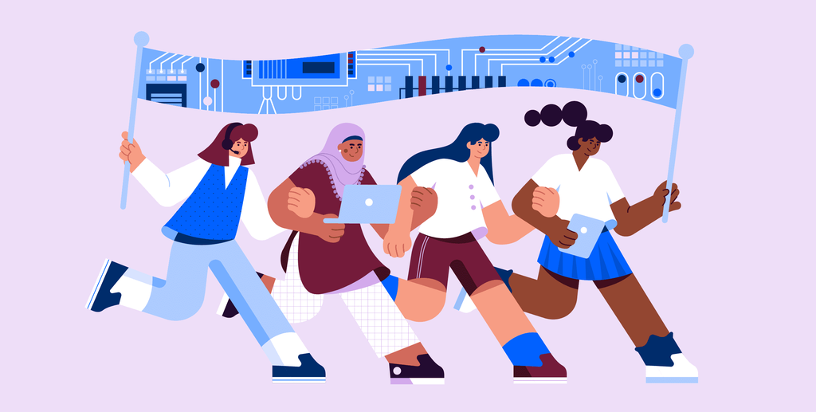

Image Courtesy of stackadapt.com

# Introduction

Hi all!

As a young women who will be getting a degree closely related to computer science soon, I am curious to see any potential trends that can be found in this specific cs professional sector.

*A few comments to mention before conducting this analysis*:

- The data collected has been separated into men’s and women’s categories, this is in no way meant to dismiss trans women in this industry, it is simply how government agencies have separated the data.
- It is also understood that is it not required to have gotten a degree (technology related or not) to be able to work in the technology field. For the sake of drawing conclusions I am using data on women who have gotten computer science degrees in the United States.
- Thirdly, throughout the project I will be using percentages instead of total number for working and degrees to get a better idea of the differences between women and men in this industry.

# Exploratory Data Analysis

First, I am importing the datasets I have created from information found on the United States Bureau of Labor Statistics as well as the National Center for Education Statistics.

```r
working_data <- read_csv("~/Desktop/working_data.csv")
degree_data <- read_csv("~/Desktop/Degree_data.csv")
ts_regression <- read_excel("~/Desktop/ts_regression.xlsx")
```

The steps to time series analysis:

1. Exploratory Data Analysis
2. Decomposing
3. Stationarity Check
4. Model Fitting
5. Diagnostic Checks
6. Forecasting
7. Conclusion

### Creating TS class

```r
men_pct_ts =ts((working_data[,6]), start = c(2012,1), end = c(2022,12), frequency = 12)
wmn_pct_ts = ts((working_data[,5]), start = c(2012,1), end = c(2022,12), frequency = 12)
```

Let’s look into the monthly data for women holding positions in technology. The following is a sample of the data collected from the USBLS.

```r
head(working_data)
```

| Month,Year | female_employment(thousands) | total_employment(thousands) | male_employment(thousands) | PCTWMN | PCTMEN |
| --- | --- | --- | --- | --- | --- |
| Jan-12 | 67.7 | 225.7 | 158.0 | 30.0 | 70.0 |
| Feb-12 | 68.3 | 225.4 | 157.1 | 30.3 | 69.7 |
| Mar-12 | 69.5 | 226.4 | 156.9 | 30.7 | 69.3 |
| Apr-12 | 69.0 | 224.0 | 155.0 | 30.8 | 69.2 |
| May-12 | 68.4 | 223.5 | 155.1 | 30.6 | 69.4 |
| Jun-12 | 67.4 | 222.4 | 155.0 | 30.3 | 69.7 |

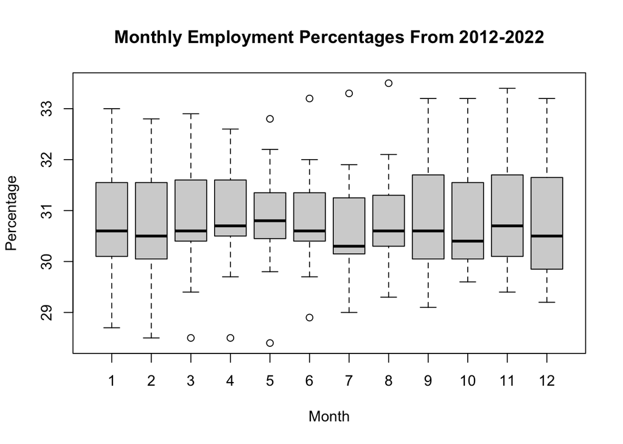

```r
boxplot(wmn_pct_ts~cycle(wmn_pct_ts),main="Monthly Employment Percentages From 2012-2022", xlab = "Month", ylab = "Percentage")
```

We can see from the boxplot above that the mean stays consistent throughout the year. We do see outliers from the months March to August as well as a smaller range for these months.

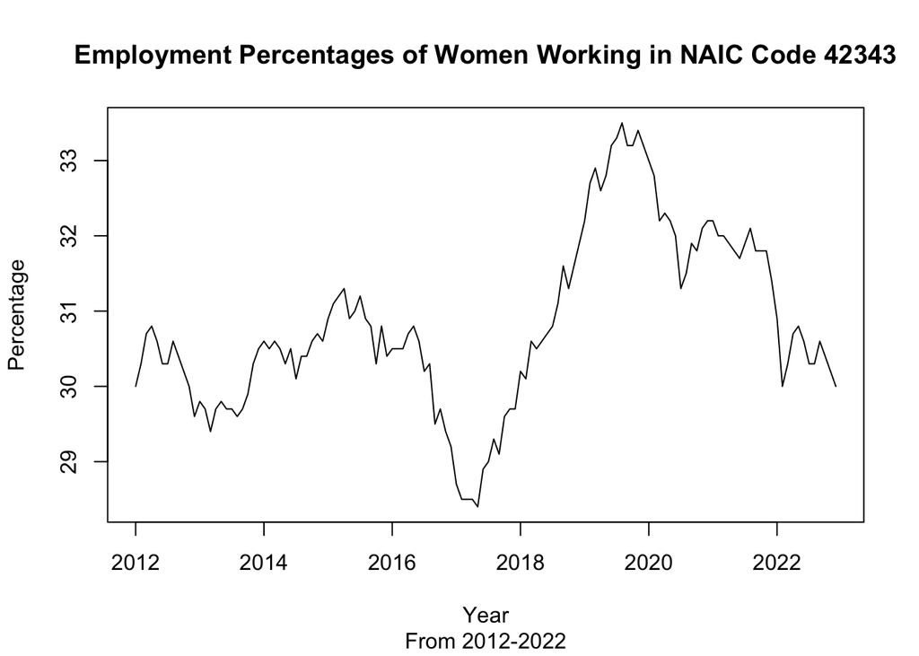

```r
plot(wmn_pct_ts,main="Employment Percentages of Women Working in NAIC Code 42343", sub="From 2012-2022", xlab = "Year", ylab = "Percentage")
```

### Decomposing

As we have monthly data for the women working in technology dataset, it would be worthwhile to decompose the model to look for seasonal trends.

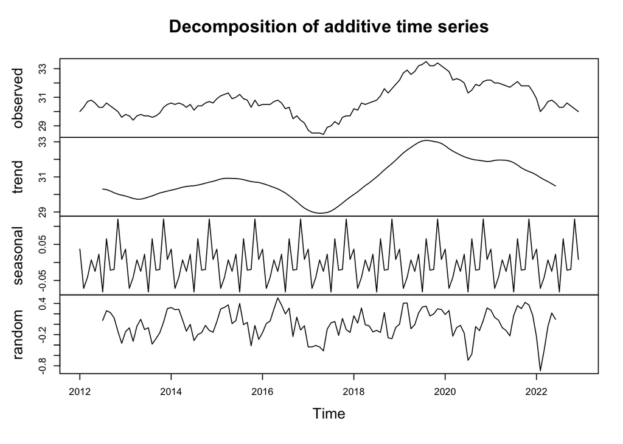

```r
wmnpct_decomp = decompose(wmn_pct_ts)

plot(wmnpct_decomp)
```

We can see from the trend component of the decomposed plot that the mean is changing over time, which points to non-stationary. Additionally, there does not seem to be a dramatic seasonal component from the decomposed plot. The random noise component of the decomposed plot seems to mirror a similar pattern of troughs in the data in 2017 and 2022, meaning the drops observed will likely not impact the time series analysis.It would be helpful here to conduct an ADF Test to obtain a p-value for our model. The p-value will help us to confirm if this data is indeed non-stationary.

```r
adf.test(wmn_pct_ts)
```

```
##
##  Augmented Dickey-Fuller Test
##
## data:  wmn_pct_ts
## Dickey-Fuller = -2.2999, Lag order = 5, p-value = 0.4518
## alternative hypothesis: stationary
```

The p-value here is 0.4518, which means we fail to reject the null at the Alpha Significance Level of 5%. With the ADF Test and the visuals from the original and decomposed plot, it is safe to say the time series model is non-stationary.

### Differencing and Log Transformations

To help solve the issue of non-stationarity, I will difference the model. Differencing finds the difference of consecutive observations in the data to eliminate trend.

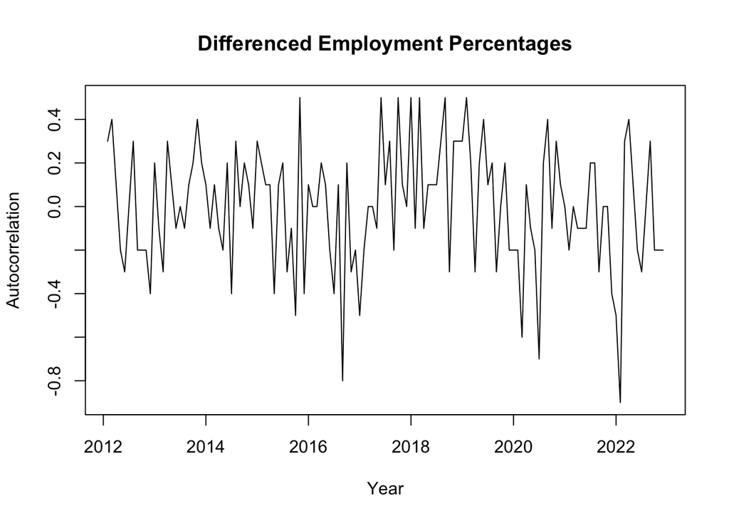

```r
wmn_pct_diff = diff(wmn_pct_ts)

plot(wmn_pct_diff,main="Differenced Employment Percentages", xlab = "Year", ylab = "Autocorrelation")
```

By plotting this differenced model, we can see that the mean is now steady across time, meaning a first-order difference was all that was needed to make this data stationary. The variance is not showing an issue here, meaning it does not greatly change over time, therefore it would not be beneficial to continue to the log transformation steps to change the stationarity of this model. To confirm stationarity it would be a good idea to check the ADF and ACF Tests.

```r
adf.test(wmn_pct_diff)
```

```
##
##  Augmented Dickey-Fuller Test
##
## data:  wmn_pct_diff
## Dickey-Fuller = -3.2049, Lag order = 5, p-value = 0.09018
## alternative hypothesis: stationary
```

The ADF Test here still gives us a p-value above the Alpha Significance Level of .05, which would mean we fail to reject the null and that the data is non-stationary. One thing to note is that the p-value did decrease roughly .3 after creating a differenced model. It would be best to conduct an ACF Test as well to confirm stationarity.

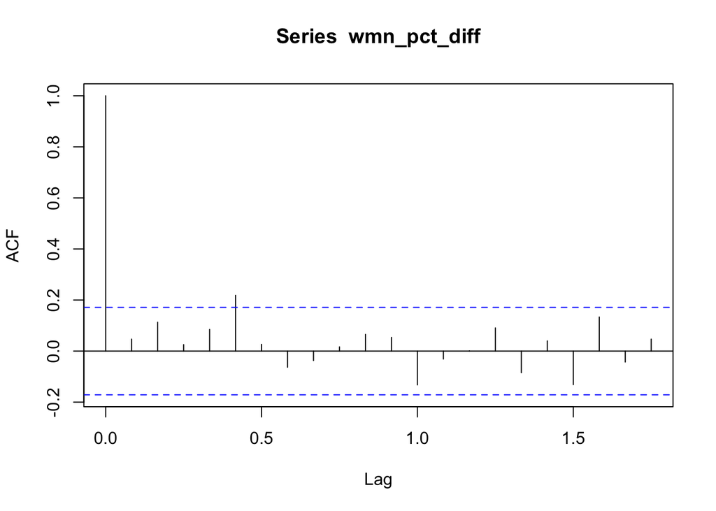

```r
acf(wmn_pct_diff)
```

# Model Fitting

To select a model for this data, we must look at the PACF as well as the ACF above.

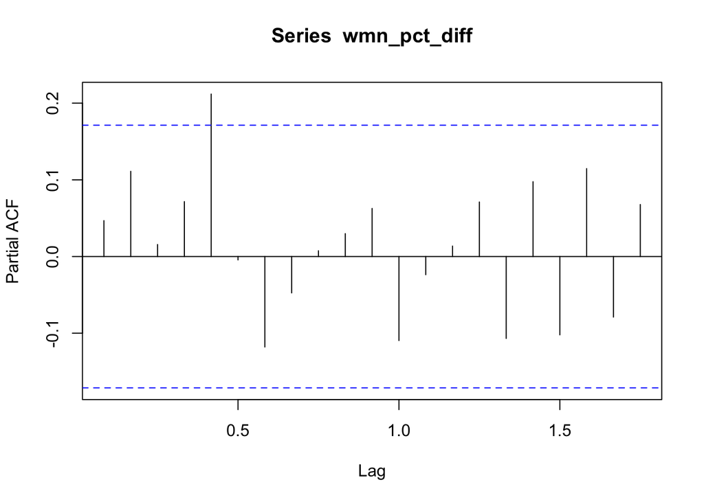

```r
pacf(wmn_pct_diff)
```

The ACF and PACF models are indicating that the data is White Noise, meaning that we will not **need** to fit an AR(p), MA(q), or ARMA(p,q) models. Although, there is a slight lag around time 5 in the ACF plot, so I am going to try to fit an AR(5) model, run diagnostic tests, and see what we get.

### AR(5) Model

```r
ar5model = arima(wmn_pct_ts, order = c(5,1,0), include.mean=F)
ar5model
```

```
##
## Call:
## arima(x = wmn_pct_ts, order = c(5, 1, 0), include.mean = F)
##
## Coefficients:
##          ar1     ar2      ar3     ar4     ar5
##       0.0214  0.0951  -0.0089  0.0682  0.2153
## s.e.  0.0854  0.0857   0.0861  0.0859  0.0862
##
## sigma^2 estimated as 0.07311:  log likelihood = -14.69,  aic = 41.39
```

The parameter estimates for the AR(5) model are as follows:

Thi estimation (0.2153)

Standard Error Estimation (0.0862)

Variance Estimation (0.07311)

In addition to the AR(5), I will test an AR(4) and an AR(6) as well to be sure that an AR(5) is the best model for the data

```r
ar4model = arima(wmn_pct_ts, order = c(4,1,0), include.mean=F)
ar4model
```

```
##
## Call:
## arima(x = wmn_pct_ts, order = c(4, 1, 0), include.mean = F)
##
## Coefficients:
##          ar1     ar2     ar3     ar4
##       0.0391  0.1044  0.0165  0.0715
## s.e.  0.0872  0.0878  0.0877  0.0881
##
## sigma^2 estimated as 0.07671:  log likelihood = -17.72,  aic = 45.45
```

```r
ar6model = arima(wmn_pct_ts, order = c(6,1,0), include.mean=F)
ar6model
```

```
##
## Call:
## arima(x = wmn_pct_ts, order = c(6, 1, 0), include.mean = F)
##
## Coefficients:
##          ar1     ar2      ar3     ar4     ar5      ar6
##       0.0217  0.0952  -0.0089  0.0684  0.2153  -0.0015
## s.e.  0.0875  0.0860   0.0861  0.0866  0.0862   0.0885
##
## sigma^2 estimated as 0.07311:  log likelihood = -14.69,  aic = 43.39
```

```r
ar5model
```

```
##
## Call:
## arima(x = wmn_pct_ts, order = c(5, 1, 0), include.mean = F)
##
## Coefficients:
##          ar1     ar2      ar3     ar4     ar5
##       0.0214  0.0951  -0.0089  0.0682  0.2153
## s.e.  0.0854  0.0857   0.0861  0.0859  0.0862
##
## sigma^2 estimated as 0.07311:  log likelihood = -14.69,  aic = 41.39
```

To find the best model for our data, we use the Akaike Information Criterion (AIC), which tells us how well the model fits the data without over-fitting.

The AIC for each model are as follows:

AR(4) AIC : 45.45 AR(5) AIC : 41.39 AR(6) AIC : 43.39

The AR(5) model has the lowest AIC (need to do the AICC as well) of the three test models. In addition to the AIC’s, the ACF and PACF indicated an AR(5) as well, therefore I will test the diagnostics for this model.

# Diagnostic Checks

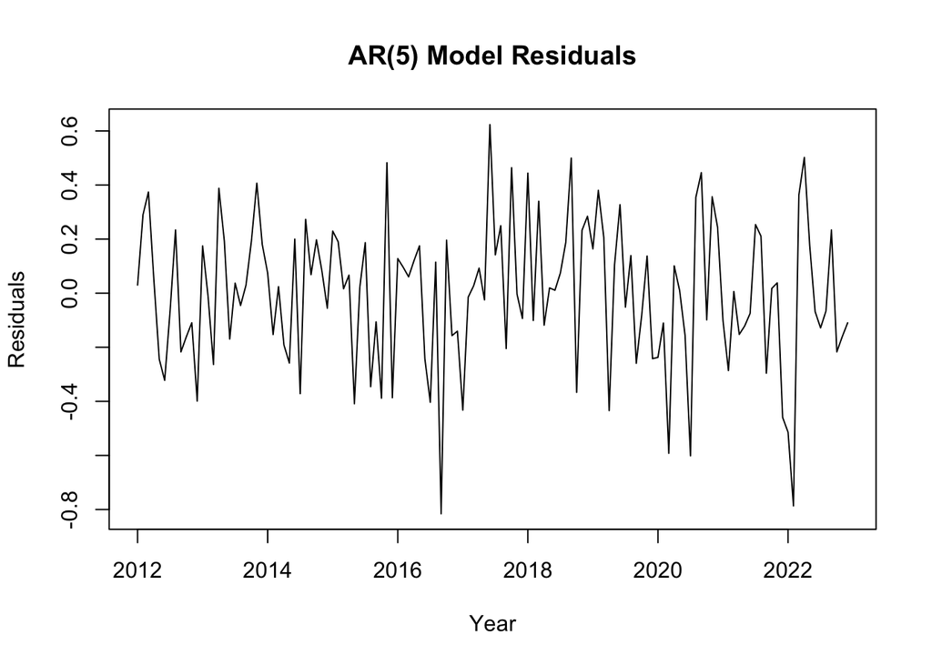

```r
plot(ar5model$residuals,main="AR(5) Model Residuals", xlab = "Year", ylab = "Residuals")
```

The plot above seems to be predominantly white noise. Although, there seem to be two sharp drops, one in early 2017 and one in early 2022, this follows the same EDA pattern found in the first plot of the data.

### Plotting ACF and PACF

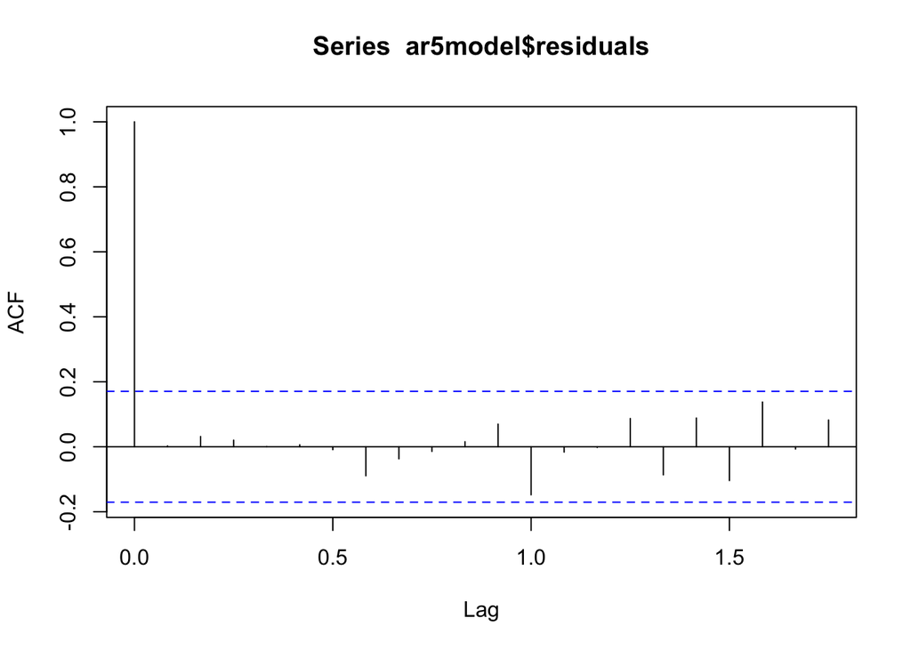

```r
acf(ar5model$residuals)
```

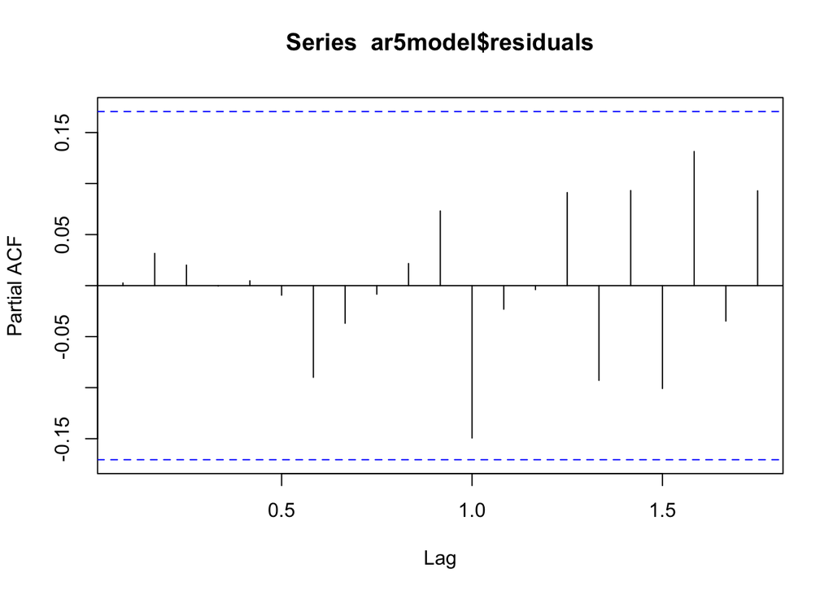

```r
pacf(ar5model$residuals)
```

The ACF and PACF also show white noise as all of the lag points are staying within the boundaries of the 95% confidence interval.

### Shaprio-Wilks and Ljung Box

*Shapiro-Wilks Hypothesis*

Ho - The data comes from a normally distributed population

Ha - The data doesn’t come from a normally distributed population

*Ljung-Box Hypothesis*

Ho - The data are independently distributed

Ha - The data are not independently distributed

```r
shapiro.test(ar5model$residuals)
```

```
##
##  Shapiro-Wilk normality test
##
## data:  ar5model$residuals
## W = 0.98881, p-value = 0.3638
```

```r
Box.test(ar5model$residuals, lag = 20, type = "Ljung-Box")
```

```
##
##  Box-Ljung test
##
## data:  ar5model$residuals
## X-squared = 13.706, df = 20, p-value = 0.8451
```

With the results from the Shapiro-Wilks test, we fail to reject the null hypothesis, therefore the data suggest it comes from a normally distributed population.

With the results from the Ljung-Box test, we fail to reject the null hypothesis, therefore the data suggests it comes from an independently distributed population and we do not have evidence of serial correlation.

### Check normality of residuals

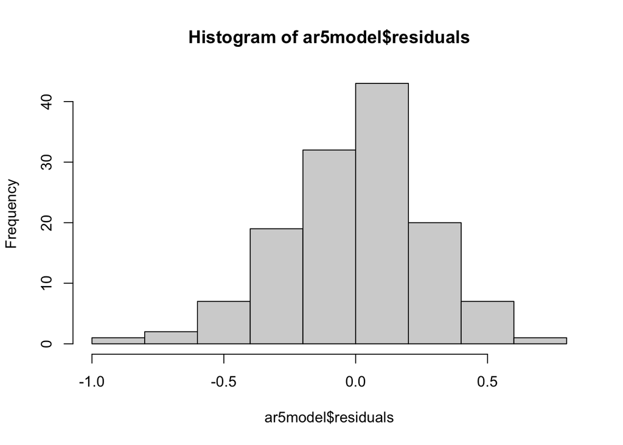

```r
hist(ar5model$residuals)
```

The histogram above shows a slight left-skew, but is unimodal and seems to follow a normal distribution pretty closely.

Overall, all of the diagnostic checks support the conditions for the AR(5) being a good fit for the data. Therefore, we are confident that the AR(5) is a good model for this data and can be used to obtain forecasted values.

# Forecasting

For my forecasted model, I have chosen to forecast the next 12 months of data which will project until December of 2023.

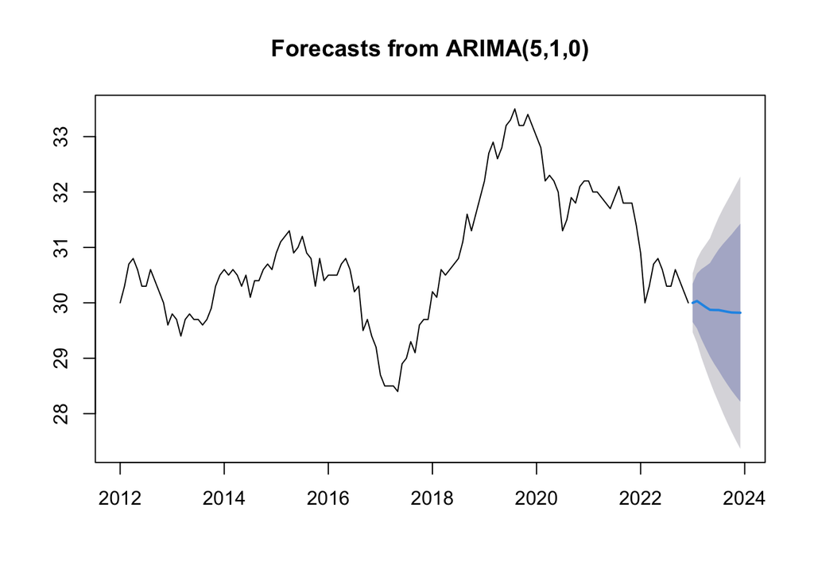

```r
forecast_model = forecast(ar5model, h =12)
table = data.frame(forecast_model)
plot(forecast_model)
```

```r
print(table[1])
```

```
##          Point.Forecast
## Jan 2023       29.99895
## Feb 2023       30.03264
## Mar 2023       29.97833
## Apr 2023       29.92368
## May 2023       29.87391
## Jun 2023       29.87020
## Jul 2023       29.86943
## Aug 2023       29.85408
## Sep 2023       29.83855
## Oct 2023       29.82580
## Nov 2023       29.82333
## Dec 2023       29.82099
```

As seen from the output above, the forecasted values for women working in the Computer and Software (NAIC Code 42343) sector has a very very small range, which decrease slighly over 12 months. Of all 12 forecasted values, none deviate greater than .18 points away from 30% of employment.

## Conclusion

After conducting the time series analysis on the US Bureau of Labor Statistics data, I can conclude that time is not a significant indicator of percentage of employment for women in the Computer and Software Service Providing Sector. I believe that if I had data that went farther back, say 30 or 40 years, I would have likely seen more signal and could have made a different conclusion relating time to job percentages.

Despite time not being a factor for this data, I would like to look into how the number of computer science Bachelor’s Degrees awarded to women impacts the number of jobs women hold within NAIC code 4243. As the explanatory variable is no longer time, I will have to conduct a time series regression analysis.

# Time Series Regression

The steps to time series regression:

1. Exploratory Data Analysis*
2. Model Fitting
3. Residual Checks
4. Conclusion

*Boxplots and Decomposition are not applicable for this data as it is yearly, and therefore has a frequency of 1.

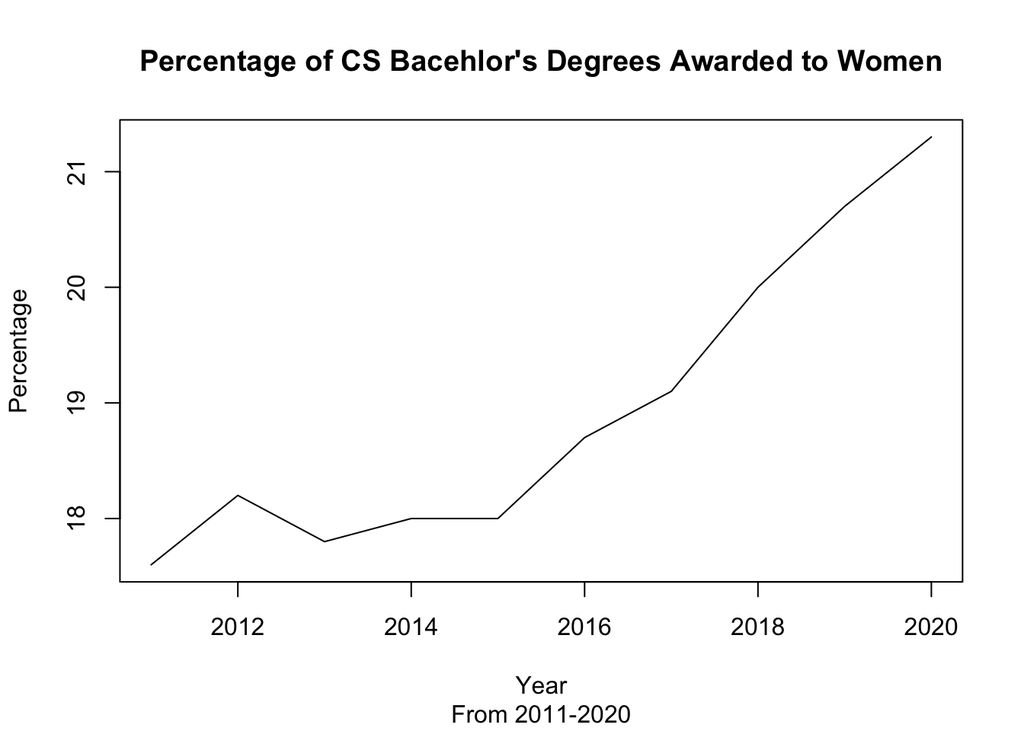

```r
plot(bac_wmn_pct,main="Percentage of CS Bacehlor's Degrees Awarded to Women", sub = "From 2011-2020", xlab = "Year", ylab = "Percentage")
```

There is a clear upward trend in the percentage of Computer Science Bachelor’s degrees awarded to women. Let’s see what the trend looks like compared to the percentage of women working to see if any patterns can be visually observed.

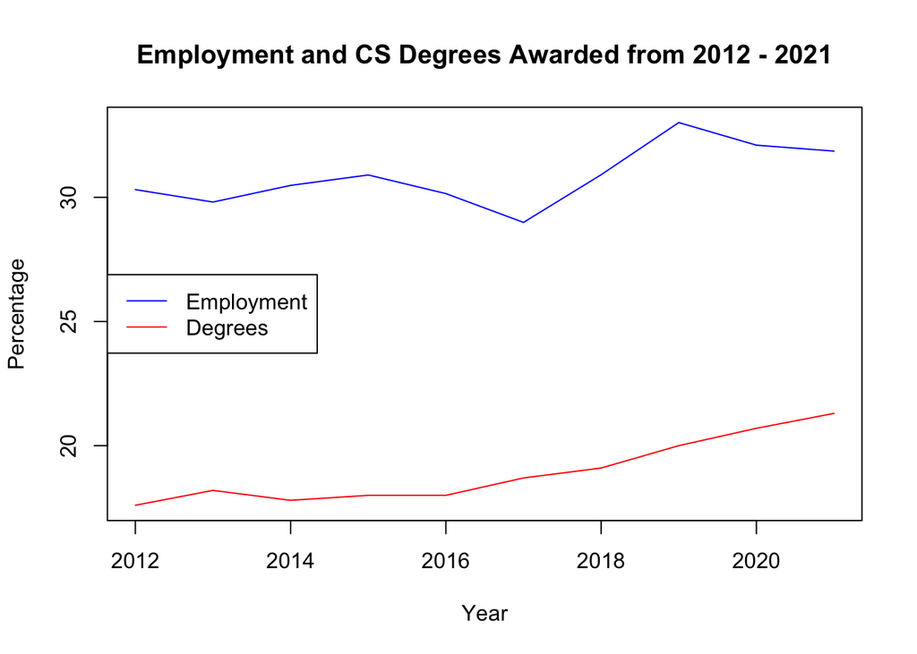

```r
ts.plot(cbind(bac_pct, working_pct), gpars = list(col=c("red", "blue"),main = "Employment and CS Degrees Awarded from 2012 - 2021" ,xlab = "Year", ylab= "Percentage"))
legend("left", legend = c("Employment", "Degrees"), col=c("blue", "red"), lty=1)
```

After plotting both the percentage of computer science degrees awarded to women as well as the employment percentage for women in NAIC code 42343, we can see that there seems to be a slight upward trend in both around early 2017. Neither line shows dramatic variance or trend. After observing the data together, we can move onto fitting a regression model.

## Model Fit and Residual Checks

```r
reg_fit = lm(working_percent ~ bac_percent, data = ts_regression)
coef(reg_fit)
```

```
## (Intercept) bac_percent
##   18.639393    0.644805
```

```r
summary(reg_fit)
```

```
##
## Call:
## lm(formula = working_percent ~ bac_percent, data = ts_regression)
##
## Residuals:
##      Min       1Q   Median       3Q      Max
## -1.70725 -0.40928  0.03399  0.35282  1.47451
##
## Coefficients:
##             Estimate Std. Error t value Pr(>|t|)
## (Intercept)  18.6394     4.3286   4.306  0.00259 **
## bac_percent   0.6448     0.2281   2.827  0.02224 *
## ---
## Signif. codes:  0 '***' 0.001 '**' 0.01 '*' 0.05 '.' 0.1 ' ' 1
##
## Residual standard error: 0.8916 on 8 degrees of freedom
## Multiple R-squared:  0.4998, Adjusted R-squared:  0.4373
## F-statistic: 7.994 on 1 and 8 DF,  p-value: 0.02224
```

From the regression model created, the output gives a p-value of 0.02224 which is a statistically significant at the Alpha Significance Level of 0.05. The data suggests that there is a relationship between percentage of degrees and percentages of workers. Additionally, the Adjusted R-Squared value is 0.437, meaning roughly 44% of the variability in percentage of workers can be associated with it’s relationship with CS degrees awarded.

The coefficients for the model can be interpreted as:

Intercept: With percentage of degrees awarded held to 0, the percentage of women working in the Computer and Software service providing sector would be at 18.639

Slope: For every 1% increase in the percentage of CS degrees awarded to women, we can predicted that there will be a 0.644 of percentage point increase in the percentage of women working in the Computer and Software service providing sector

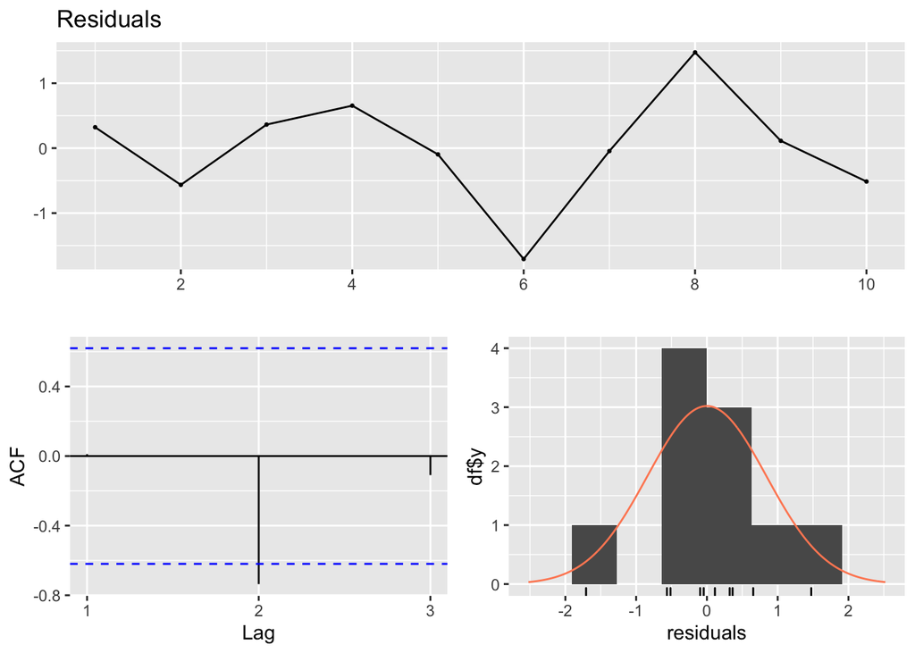

```
##
##  Breusch-Godfrey test for serial correlation of order up to 5
##
## data:  Residuals
## LM test = 8.6815, df = 5, p-value = 0.1225
```

```r
checkresiduals(reg_fit)
```

### Breusch-Godfrey Test Interpretation

H0: There is no autocorrelation at any order less than or equal to p

HA: There exists autocorrelation at some order less than or equal to p

From the Breusch-Godfrey test, our regression residuals yield a p-value of 0.1225. Therefore we fail to reject the null hypothesis and the data suggests that there is no autocorrelation at any order less than or equal to 5.

### Histogram Interpretation

The histogram of the residuals shows a slight skew. Despite this, it seems to follow a normal distribution.

### Residual Plot Against Predictors

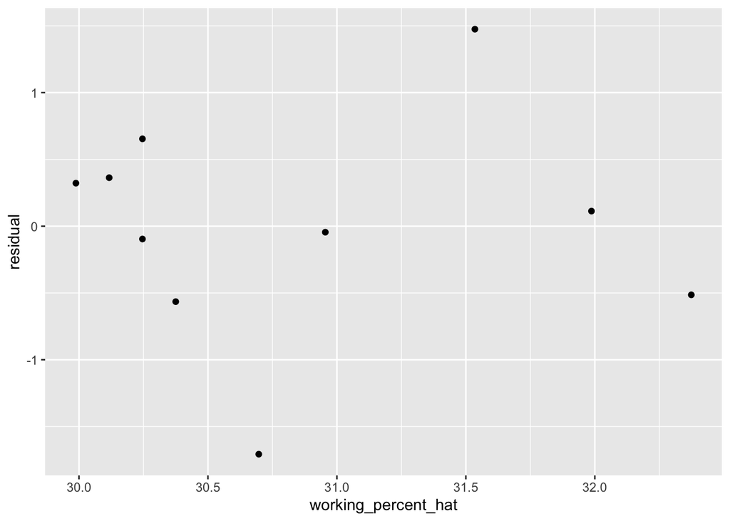

```r
residual_table = get_regression_points(reg_fit)
gf_point(residual ~ working_percent_hat, data = residual_table, main = "Residuals Against Predicted Values")
```

From the graph above I see a slight megaphone shape, this might come from the small number of observations in the dataset. From the graph we can also see that there are no X no Y outliers.

Overall, the residual checks for this regression model all seem to pass, with the caveat of having a dataset with less observations than are ideal.

# Overall Conclusion

Overall, it can be concluded that time is not an indicator variable for the percentage of women working in NAIC code 42343 but the percentage of CS degrees awarded to women has a slight positive relationship with percentage of women working. I predict if more data was available from 30-40 years ago, as opposed to the last 10 years, time might have had more of an impact on working percentages. In the future I would be interested in looking at other predictor variables that may have an impact on women working in the CS field, as well as revisiting this analysis in the far future when more data is available through the USBLS.